# Function and Loop Cases

```r
library(tidyverse)
library(lubridate)
library(nycflights13)
# sample dataset to make plots faster
flights <- as_data_frame(flights) %>%
  sample_n(1000)
```

# Iris exploration

1. Calculate the mean of all columns
2. Calculate the mean for all columns per `Species`

```r
tmp <- iris %>%
  group_by(Species) %>%
  nest() %>%
  mutate(
    means = map(data, ~summarise_all(.x, mean))
  ) %>%
  unnest()
```

```
Error: All nested columns must have the same number of elements.
```

# Gapminder

1. Check which countries have an interesting history based on the r squared of the fitted models over time

# Flights exploration plots

1. Make a point plot of the `arr_delay` with the following columns:
- `dep_time`
- `dep_delay`
- `air_time`
- `distance`
1. Make a linear model between the priviously mentioned variables and `arr_delay` and select the coefficients of the model with the highst `r.squared`

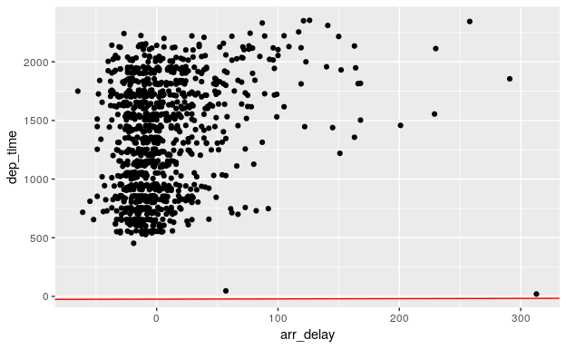

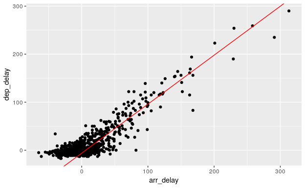

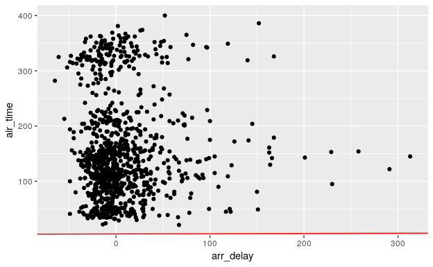

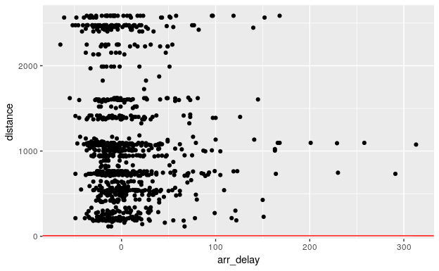

```r
map2(models$variable, models$coefs, ~plot_arr_delay_with_model(.x, .y))
```

# Age calculations

1. For the 3 data frames that are given you want to add a column `age` that calculates the age based on the current year. Also set `age` to `NA` when people are older than 130 and with a negative age.
2. Set `age` to `NA` when `age` is lower than 18.
3. Now you want to do the same but the `geboortejaar` colomn has a different name in every data frame.
4. What if you have 50 data frames…

```r
df1 <- tibble(
  geboortejaar = c(1986, 1987, 19880)
)
df2 <- tibble(
  geboortejaar = c(1989, 1990, 19910)
)
df3 <- tibble(
  geboortejaar = c(1992, 1993, 19940)
)

calculate_age <- function(df) {
  df1 %>%
    mutate(
      age = year(now()) - geboortejaar,
      age = if_else(age < 130 & age > 0, age, NA_real_)
    )
}

df1 <- df1 %>%
  calculate_age()
df2 <- df2 %>%
  calculate_age()
df3 <- df3 %>%
  calculate_age()

df1 <- tibble(
  geboortejaar = c(1986, 1987, 1988)
)
df2 <- tibble(
  gebjaar = c(1989, 1990, 1991)
)
df3 <- tibble(
  born = c(1992, 1993, 1994)
)

calculate_age <- function(df, birth_year_column) {
  birth_year_column <- enquo(birth_year_column)
  df %>%
    mutate(age = year(now()) - !!birth_year_column)
}

df1 <- df1 %>%
  calculate_age(geboortejaar)
df2 <- df2 %>%
  calculate_age(gebjaar)
df3 <- df3 %>%
  calculate_age(born)

df_list <- list(df1, df2, df3)
birth_year_column_list <- c(quote(geboortejaar), quote(gebjaar), quote(born))
birth_year_column_list <- map(c("geboortejaar", "gebjaar", "born"), sym)

df_list <- df_list %>%
  map2(birth_year_column_list, calculate_age)
```

# Re-coding variables

1. Set for all the columns in the data frame all the values higher than 5 to `NA`
2. Now for only the columns 1, 2 and 3.
3. The `allowed_column_values` list contains which values are allowed for every column. Try to set all the other values of the columns to `NA`

```r
recode(df[[names[1]]], allowed_column_values[[names[1]]])
```

```
 [1]  1 NA NA NA NA NA NA NA NA NA
```